# L10 Factors

Data Science 1 with R (STAT 301-1)

Author

INSTRUCTIONS

## Overview

The goal of this lab is to learn how to deal with factors in R, specifically within the tidyverse (although many of these methods can be applied with base R functions as well). Factors are used to work with categorical variables, or variables that have a fixed and known set of possible values. We’ll use the `forcats` package, which provides tools for dealing with categorical variables.

For more information on the `forcats` package, see [`forcats` tidyverse homepage](http://forcats.tidyverse.org/reference/index.html).

## Load Packages

```r
# Loading package(s)
```

## Datasets

We will be using the `gss_cat` dataset that is included in the `forcats` package. To view the documentation for the dataset, use `?gss_cat`.

## Exercises

### Exercise 1

Create a bar chart to explore the distribution of `rincome` (reported income). What makes the default bar chart hard to understand? Improve the bar chart.

### Exercise 2

What is the most common `relig` in this survey? What’s the most common `partyid`?

### Exercise 3

Which `relig` does `denom` (denomination) apply to? Create a visualization to find out.

### Exercise 4

There are some suspiciously high numbers in `avg_tvhours` (mean or average of `tvhours`). Since the mean is not robust to outliers, it is not a good summary of this variable. Create a graphic similar to the one below, but use a more appropriate summary of `tvhours`.

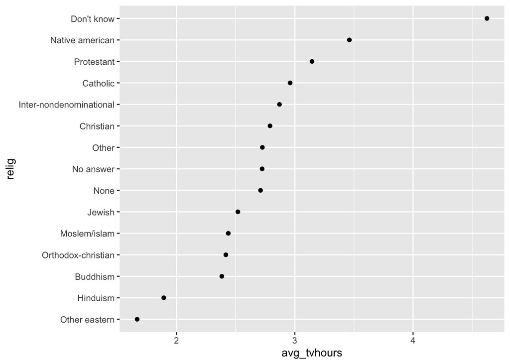

### Exercise 5

How have the proportions of people who identify as Democrat, Republican, and Independent changed over time the time period from 2000 to 2014? Build a visualization to display this information. You should also write a few sentences to summarize the trends within the graphic.

### Exercise 6

Demonstrate how to collapse `rincome` into a smaller set of categories.